# Mapping in R

06 November 2018

## In a nutshell

## Packages

- [`sf`](https://cran.r-project.org/web/packages/sf/index.html) vector files
- [`raster`](https://cran.r-project.org/web/packages/raster/index.html) raster
- [`mapview`](https://cran.r-project.org/web/packages/mapview/index.html) visualize

## Resources

- https://insileco.github.io/tuto/rinspace/rinspace_homepage/
- https://geocompr.robinlovelace.net/
- http://rspatial.org/intr/index.html
- https://www.r-spatial.org/
- http://geojson.io/#map=2/20.0/0.0
- https://freegisdata.rtwilson.com/

## Why?

## Mapping in Ecology?

1. show where your plots are
2. show how variables are distributed spatially
3. spatial analyses
4. many, many tools

## R as a GIS?

1. Workflow
2. Quite efficient
3. Interface

## Workflow

### **R for everything** (*almost*)

1. import your data
2. format your data
3. analyze your data
4. visualize your data
5. export your data
6. create your own functions/packages

## Efficiency

1. well-defined classes
2. many formats (+ convert different file)
3. operations on geometries
4. statistical analyses
5. visualization

## Interface

1. C/C++: [Geos](http://trac.osgeo.org/geos), [proj4](http://proj4.org/), [Gdal](http://www.gdal.org/)
2. JavaScript: [Leaflet](https://rstudio.github.io/leaflet/)
3. otherGIS: [RQGIS](https://cran.r-project.org/web/packages/RQGIS/index.html), [rgrass7](https://cran.r-project.org/web/packages/rgrass7/index.html), [RgoogleMaps](https://cran.r-project.org/web/packages/RgoogleMaps/index.html)
4. retrieve data: osmdata

## How? An overview

## Turning R into a powerful GIS

### 1- Define classes

- `sp`
- `raster`
- `sf`

### 2- Topology operations

- `rgeos`
- `sf`

### 3- Import / export

- `rgdal`
- `sf`

## Turning R into a powerful GIS

### 4- Analyses (few examples)

- `spdep`
- `spatial`
- `gstat`
- `dismo`

### 5- Creating and editing maps

- `graphics`
- `ggplot`
- `interactive plot / web-based plot`
- [a blog post about this](https://insileco.github.io/2015/12/04/list-of-r-packages-to-create-and-edit-plots/)

## Turning R into a powerful GIS

### 6- But…

- Geo-referencing
- Visualizing large spatial objects
- Watershed analysis

## Package `sp`

## Classes

| Classes / Functions | Contents |
| --- | --- |
| Points | list of points (set of coordinates) |
| SpatialPoints | list of points + CRS |
| SpatialPointsDataPoints | list of points + CRS + attribute table |
| Line | a line (set of coordinates) |
| Lines | list of lines |
| SpatialLines | list of lines + CRS |
| SpatialLinesDataFrame | list of lines + CRS + attribute table |

## Example: `SpatialPointsDataPoints`

| long | lat | var1 | var2 |
| --- | --- | --- | --- |
| -80.95362 | 42.17096 | -0.8852481 | 3.5288935 |
| -80.36508 | 43.10166 | 1.7148959 | 6.6046439 |
| -80.65781 | 42.39208 | -0.2219311 | 0.2493644 |
| -81.42152 | 42.09180 | -2.5043391 | 6.3653082 |
| -80.78941 | 43.26784 | 0.1766467 | 3.7825111 |
| -81.10533 | 42.11308 | -0.8977658 | 2.7027611 |

## Example: `SpatialPointsDataFrame`

```r
library(sp)
mysp <- SpatialPointsDataFrame(
  coords = mydata[,1:2],
  data = mydata[,3:4],
  proj4string = CRS(
    "+proj=longlat +ellps=WGS84 +datum=WGS84 +no_defs +towgs84=0,0,0"
  )
)
```

## Example: `SpatialPointsDataFrame`

```r
class(mysp)
```

```
## [1] "SpatialPointsDataFrame"
## attr(,"package")
## [1] "sp"
```

```r
isS4(mysp)
```

```
## [1] TRUE
```

```r
slotNames(mysp)
```

```
## [1] "data"        "coords.nrs"  "coords"      "bbox"        "proj4string"
```

## Example: `SpatialPointsDataFrame`

```r
mysp@proj4string
```

```
## CRS arguments:
##  +proj=longlat +ellps=WGS84 +datum=WGS84 +no_defs +towgs84=0,0,0
```

```r
head(mysp@data)
```

```
##         var1      var2
## 1 -0.8852481 3.5288935
## 2  1.7148959 6.6046439
## 3 -0.2219311 0.2493644
## 4 -2.5043391 6.3653082
## 5  0.1766467 3.7825111
## 6 -0.8977658 2.7027611
```

## Change projection: `spTransform`

```r
(mysp2 <- spTransform(mysp, CRS=CRS("+proj=merc +ellps=GRS80")))
```

```
##            coordinates         var1      var2
## 1  (-9011715, 5157929) -0.885248073 3.5288935
## 2  (-8946200, 5298253)  1.714895877 6.6046439
## 3  (-8978786, 5191078) -0.221931147 0.2493644
## 4  (-9063802, 5146090) -2.504339144 6.3653082
## 5  (-8993436, 5323533)  0.176646727 3.7825111
## 6  (-9028604, 5149271) -0.897765848 2.7027611
## 7  (-8985002, 5428508) -1.004612170 6.5370860
## 8  (-8987188, 5403104)  0.081480485 5.6064616
## 9  (-9112177, 5406733)  0.887519582 2.6685859
## 10 (-9121702, 5410634)  0.175649243 4.2287652
## 11 (-8916394, 5286647) -0.143991329 9.3165423
## 12 (-8908251, 5423223)  0.014687077 1.1272343
## 13 (-9103152, 5331383) -0.448895976 3.3232480
## 14 (-9121535, 5338572)  0.561188239 0.2582339
## 15 (-9126676, 5419720) -0.825143542 2.2148579
## 16 (-9032011, 5147282)  0.993920452 1.3432549
## 17 (-9035231, 5326703) -0.003455062 7.2756258
## 18 (-9080838, 5387184) -0.660376744 7.6992890
## 19 (-8994340, 5360932)  0.276733107 8.9131325
## 20 (-9047506, 5136935)  0.339732272 9.9522539
```

## Package `raster`

## Classes

### 0- SpatialGrid / SpatialPixel (package `sp`)

### 3- RasterLayer (package `raster`)

### 4- RasterStack (package `raster`)

### 5- RasterBrick (package `raster`)

## Example: `raster`

```r
library(raster)
ras1 <- raster(matrix(runif(100*100,0,10),ncol=100,nrow=100),
    crs=CRS("+proj=longlat +datum=WGS84 +no_defs +ellps=WGS84 +towgs84=0,0,0"),
    xmn=-82, xmx=+80, ymn=+42, ymx=+44)
```

## Example: `raster`

```r
ras1
```

```
## class       : RasterLayer
## dimensions  : 100, 100, 10000  (nrow, ncol, ncell)
## resolution  : 1.62, 0.02  (x, y)
## extent      : -82, 80, 42, 44  (xmin, xmax, ymin, ymax)
## coord. ref. : +proj=longlat +datum=WGS84 +no_defs +ellps=WGS84 +towgs84=0,0,0
## data source : in memory
## names       : layer
## values      : 0.001514384, 9.999197  (min, max)
```

## Retrieving free GIS data: `getData`

```r
head(getData("ISO3"))
```

```
##   ISO3                  NAME
## 1  AFG           Afghanistan
## 2  XAD Akrotiri and Dhekelia
## 3  ALA                 Åland
## 4  ALB               Albania
## 5  DZA               Algeria
## 6  ASM        American Samoa
```

## Example: `getData`

```r
## Country level:
mapBEL0 <- getData(name="GADM", country="BEL", path="./assets", level=0)
mapBEL1 <- getData(name="GADM", country="BEL", path="./assets", level=1)
tminW <- getData(name="worldclim", var="tmin", res=10, path="./assets")
mapBEL0
```

```
## class       : SpatialPolygonsDataFrame
## features    : 1
## extent      : 2.555356, 6.40787, 49.49722, 51.50382  (xmin, xmax, ymin, ymax)
## coord. ref. : +proj=longlat +datum=WGS84 +no_defs +ellps=WGS84 +towgs84=0,0,0
## variables   : 2
## names       : GID_0,  NAME_0
## value       :   BEL, Belgium
```

## Package `rgdal`

## Drivers

```r
library(rgdal)
```

1. **writeOGR** / **writeGDAL**: to write spatial objects
2. **readOGR**/**readGDAL**: to read spatial files

## Drivers

```r
head(ogrDrivers())
```

```
##         name                     long_name write  copy isVector
## 1 AeronavFAA                   Aeronav FAA FALSE FALSE     TRUE
## 2 AmigoCloud                    AmigoCloud  TRUE FALSE     TRUE
## 3     ARCGEN             Arc/Info Generate FALSE FALSE     TRUE
## 4     AVCBin      Arc/Info Binary Coverage FALSE FALSE     TRUE
## 5     AVCE00 Arc/Info E00 (ASCII) Coverage FALSE FALSE     TRUE
## 6        BNA                     Atlas BNA  TRUE FALSE     TRUE
```

## Export

```r
writeOGR(mysp, dsn="./assets", layer="mypoints",
    driver="ESRI Shapefile", overwrite_layer=TRUE)
```

## Import

```r
mysp2 <- readOGR(dsn="assets/", layer="mypoints")
## Roads find on http://www.diva-gis.org/Data
canroads <- readOGR(dsn="assets/", layer="CAN_roads")
```

*NB*: there are function to import/export raster in `raster`

## Package `rgeos`

## Load the package

```r
library(rgeos)
```

## Load the package

```r
buf <- gBuffer(mapBEL0, width=0.5)
diff <- gDifference(gBuffer(mapBEL0, width=0.5), gBuffer(mapBEL0, width=0.1))
```

## package `sf`

## Simple features?

> The package `sf` […] aims at succeeding `sp` in the long term.

> Simple features or simple feature access refers to a formal standard (ISO 19125-1:2004) that describes how objects in the real world can be represented in computers, with emphasis on the spatial geometry of these objects

https://cran.r-project.org/web/packages/sf/vignettes/sf1.html

## Importing spatial object

```r
library(sf)
mysf <- st_read(dsn="assets/mypoints.shp")
```

## Importing spatial object

```r
print(mysf)
```

```
## Simple feature collection with 20 features and 2 fields
## geometry type:  POINT
## dimension:      XY
## bbox:           xmin: -81.98633 ymin: 42.03051 xmax: -80.02418 ymax: 43.95302
## epsg (SRID):    4326
## proj4string:    +proj=longlat +datum=WGS84 +no_defs
## First 10 features:
##           var1      var2                   geometry
## 1  -0.88524807 3.5288935 POINT (-80.95362 42.17096)
## 2   1.71489588 6.6046439 POINT (-80.36508 43.10166)
## 3  -0.22193115 0.2493644 POINT (-80.65781 42.39208)
## 4  -2.50433914 6.3653082  POINT (-81.42152 42.0918)
## 5   0.17664673 3.7825111 POINT (-80.78941 43.26784)
## 6  -0.89776585 2.7027611 POINT (-81.10533 42.11308)
## 7  -1.00461217 6.5370860 POINT (-80.71365 43.95302)
## 8   0.08148049 5.6064616 POINT (-80.73328 43.78793)
## 9   0.88751958 2.6685859 POINT (-81.85608 43.81154)
## 10  0.17564924 4.2287652 POINT (-81.94164 43.83691)
```

## Importing spatial object

```r
mysf2 <- st_as_sf(mysp)
```

## Simple manipulations

## Simple manipulations

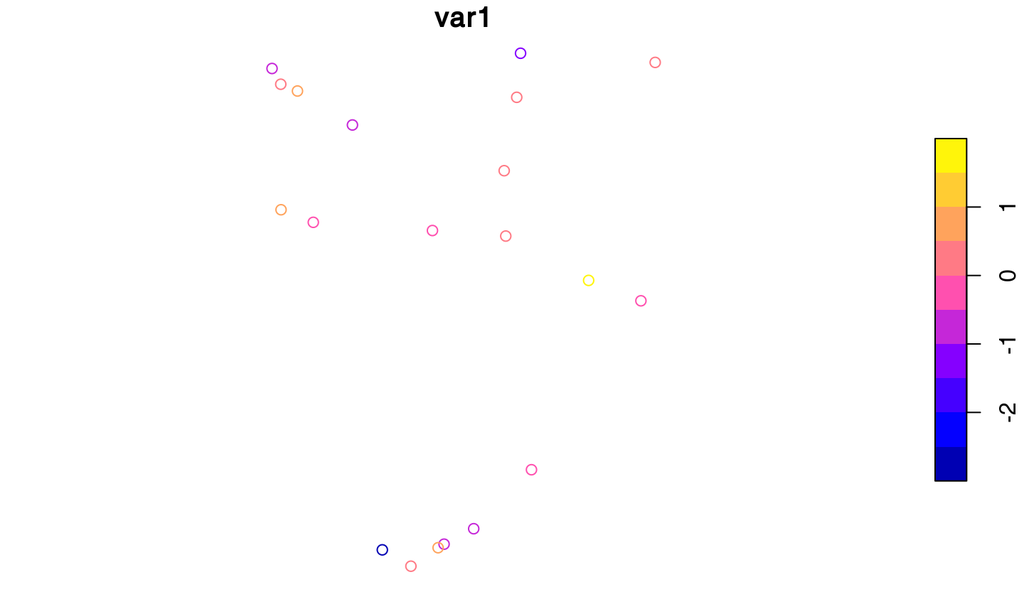

```r
plot(mysf[1])
```

```r
plot(st_buffer(mysf[1], 0.1))
```

## Simple manipulations

```
## dist is assumed to be in decimal degrees (arc_degrees).
```

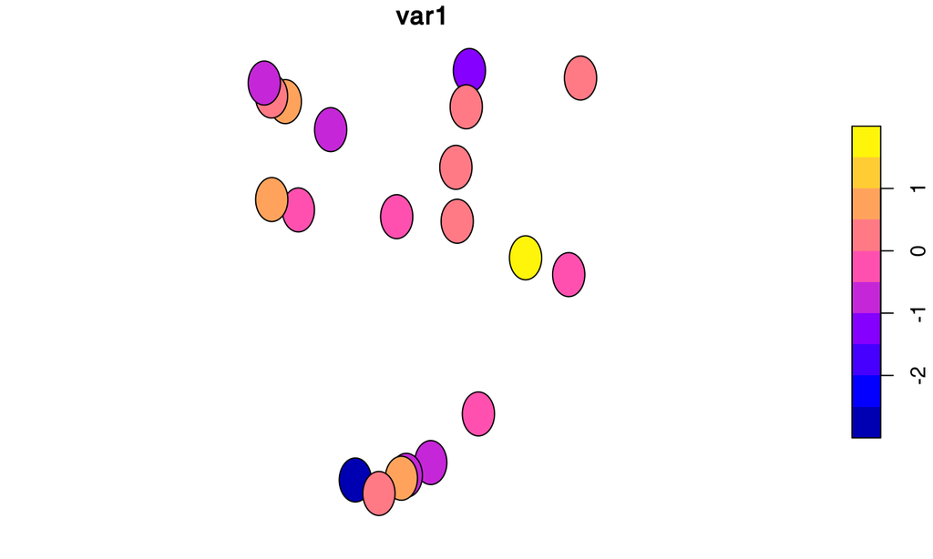

### `sf` or `sp`?

- https://insileco.github.io/2017/09/12/efficiency-of-spatial-intersects-in-r/
- https://github.com/r-spatial/sf

## Package `mapview`

## Import package

```r
library(mapview)
```

**NB:** it uses the `leaflet` package which uses `sp`.

## 1 line of code examples

```r
mapview(mysp, cex = 'var2')@map
```

[interactive chart not shown]

## Quick examples

```r
mapview(mapBEL1)@map
```

[interactive chart not shown]

## More (using `leaflet`)

- https://insileco.github.io/Elections_fr-042017/
- https://insileco.github.io/fr-departement-election/

## Editing a map

## A very basic map – Shapefile

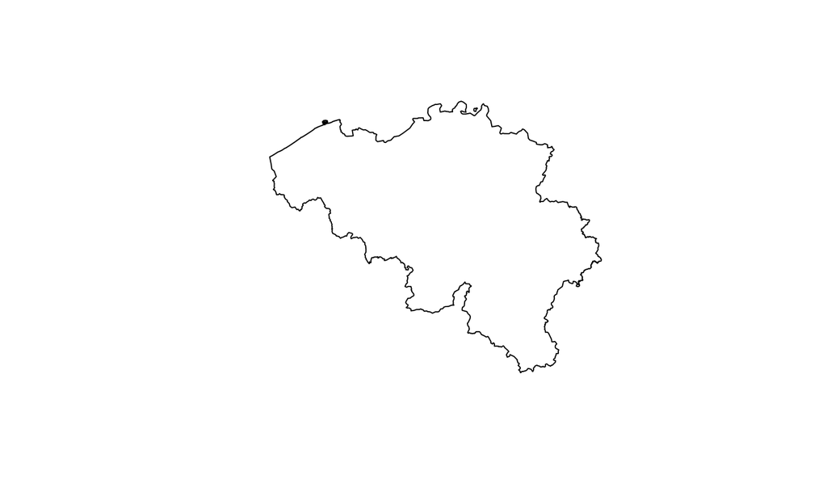

```r
plot(mapBEL0)
```

## A very basic map – Raster

```r
class(tminW)
```

```
## [1] "RasterStack"
## attr(,"package")
## [1] "raster"
```

## A very basic map – Raster

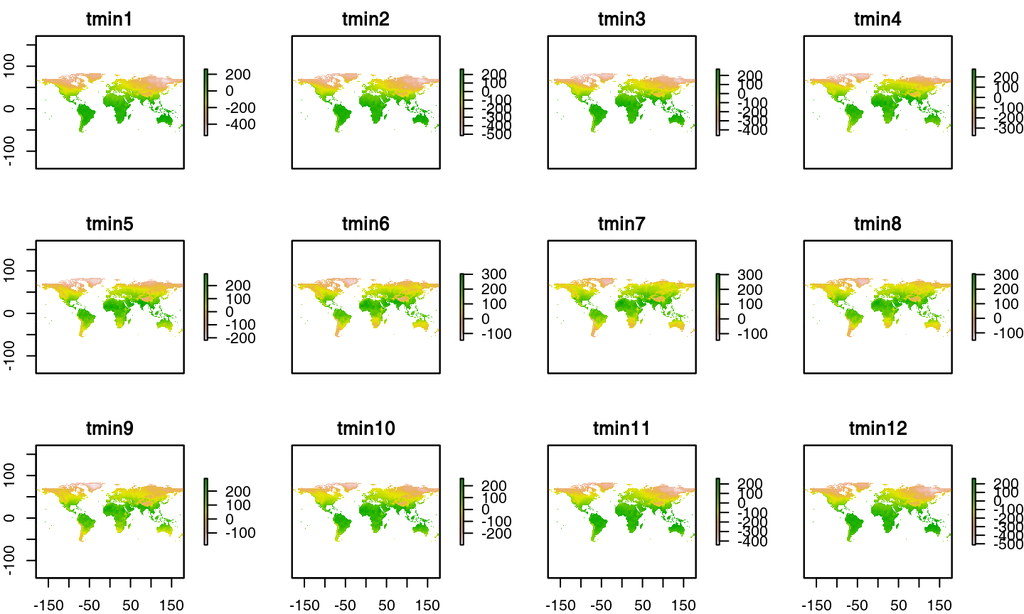

```r
plot(tminW)
```

## Customize a map – Shapefile

```r
plot(mapBEL0, border='grey15', col='#E6E6E6', lwd=1.6)
plot(mapBEL1, lty=2, lwd=0.9, add=T)
points(4.3513, 50.8471, pch=19, col="#27df9d")
text(4.3513, 50.8471, text="Brussel", pos=3)
```

## Customize a map – Shapefile

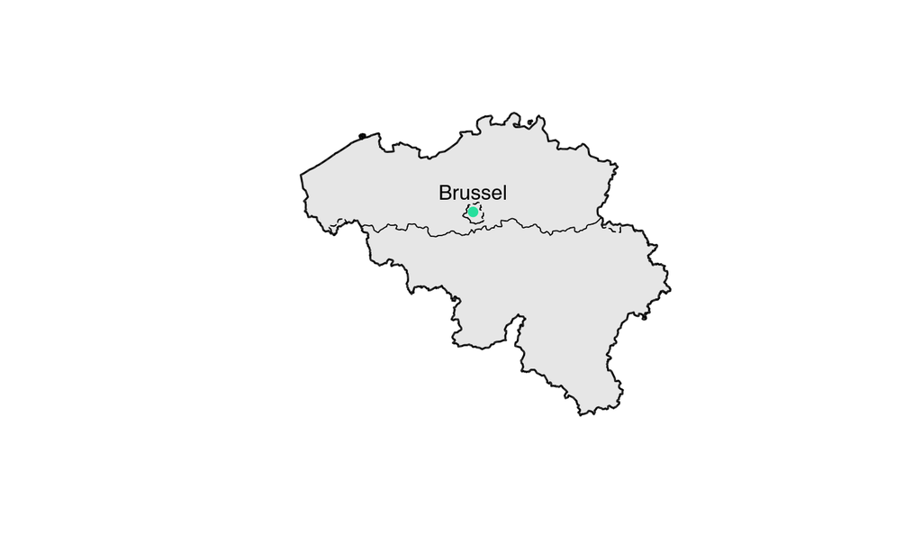

## Resources

## Useful links to use R as a GIS

- task view: https://cran.r-project.org/web/views/Spatial.html; also following to this `https://cran.r-project.org/web/views/`

```r
install.packages("ctv")
install.views("Spatial")
```

- [Document par Nicolas Casajus](https://qcbs.ca/wiki/_media/gisonr.pdf)
- http://r-spatial.org/
- http://www.rspatial.org/
- [Tutorial on datacamp](https://www.datacamp.com/courses/spatial-analysis-in-r-with-sf-and-raster)

## Useful links to get data

- [free data at country level](http://www.diva-gis.org/gdata)
- [Quebec free data](http://mffp.gouv.qc.ca/le-ministere/acces-aux-donnees-gratuites/)
- [find more spatial data](https://freegisdata.rtwilson.com/)
- [create shapefile on line](http://geojson.io/)
- EPSG: [link1](http://spatialreference.org/); [link2](http://epsg.io/)

## Let’s practice

## Installation

### 1- Have a look at https://github.com/r-spatial/sf

### 2- Install R packages

```r
install.packages(c("sf", "sp", "rgeos", "rgdal", "raster", "mapview"))
```

## Alexis’s data

```r
tmp <- read.csv('assets/Feuil2.csv')
head(tmp)
```

```
##      plot      lat       lon     elev
## 1 M-FT-01 45.44728 -71.10890 749.4448
## 2 M-FB-01 45.44738 -71.11548 908.9915
## 3 M-FM-01 45.44701 -71.11367 848.7617
## 4 M-FB-02 45.45012 -71.11455 909.0892
## 5 M-FM-02 45.44985 -71.11202 833.5641
## 6 M-FT-02 45.44917 -71.10891 738.8082
```

```r
alex <- SpatialPointsDataFrame(
  tmp[c('lon', 'lat')],
  data = tmp[c('plot', 'elev')],
  proj4string = CRS('+proj=longlat +datum=WGS84 +no_defs +ellps=WGS84 +towgs84=0,0,0')
)
head(alex)
```

```
##      plot     elev
## 1 M-FT-01 749.4448
## 2 M-FB-01 908.9915
## 3 M-FM-01 848.7617
## 4 M-FB-02 909.0892
## 5 M-FM-02 833.5641
## 6 M-FT-02 738.8082
```

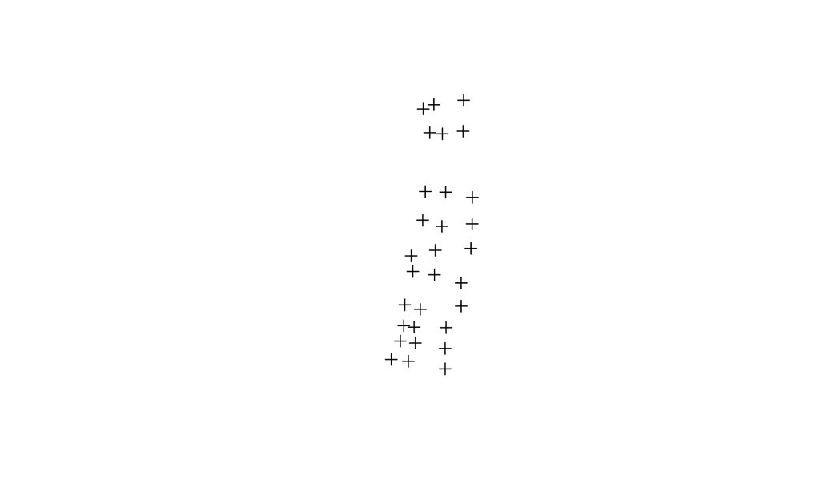

```r
plot(alex)
```

```r
mapview(alex)
```

[interactive chart not shown]

```r
coord <- coordinates(alex)
# altCAN2 <- raster::getData(name="SRTM", lon = coord[1,1], lat = coord[1,2], path="assets/")
altCAN <- raster::getData(name="alt", country = "CAN", path="assets/")
bouCAN2 <- raster::getData(country='CAN', level=2, path="assets/")
bouCAN2_Q <- bouCAN2[bouCAN2@data$NAME_1 == "Québec",]
```

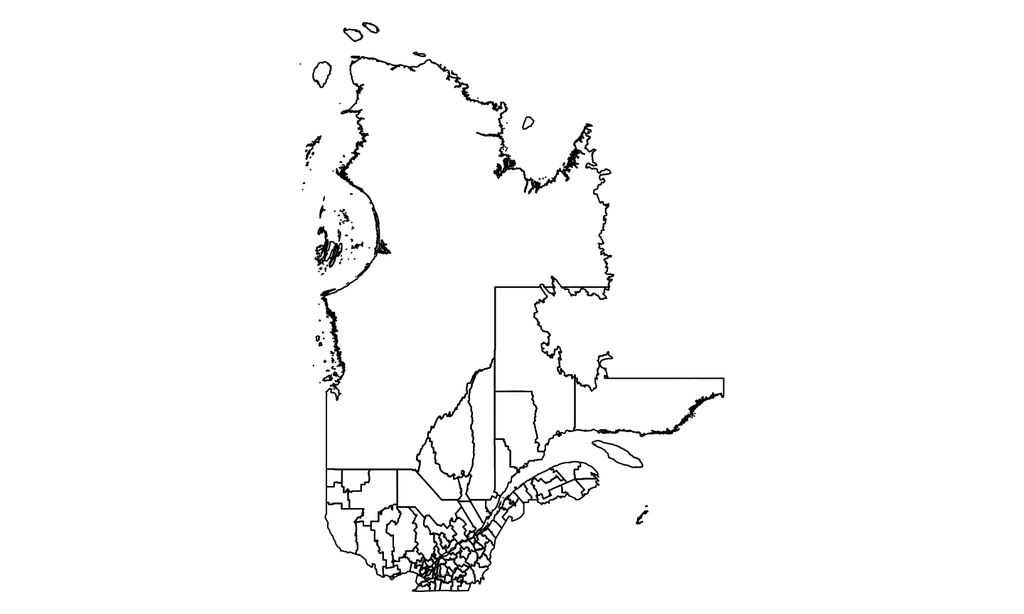

```r
par(mar=rep(0,4))
plot(bouCAN2_Q)
```

```r
al_ov <- over(alex, bouCAN2_Q)
head(al_ov)
```

```
##   GID_0 NAME_0    GID_1 NAME_1 NL_NAME_1       GID_2    NAME_2 VARNAME_2
## 1   CAN Canada CAN.11_1 Québec      <NA> CAN.11.54_1 Le Granit      <NA>
## 2   CAN Canada CAN.11_1 Québec      <NA> CAN.11.54_1 Le Granit      <NA>
## 3   CAN Canada CAN.11_1 Québec      <NA> CAN.11.54_1 Le Granit      <NA>
## 4   CAN Canada CAN.11_1 Québec      <NA> CAN.11.54_1 Le Granit      <NA>
## 5   CAN Canada CAN.11_1 Québec      <NA> CAN.11.54_1 Le Granit      <NA>
## 6   CAN Canada CAN.11_1 Québec      <NA> CAN.11.54_1 Le Granit      <NA>
##   NL_NAME_2                       TYPE_2                    ENGTYPE_2 CC_2
## 1      <NA> Regional County Municipality Regional County Municipality   30
## 2      <NA> Regional County Municipality Regional County Municipality   30
## 3      <NA> Regional County Municipality Regional County Municipality   30
## 4      <NA> Regional County Municipality Regional County Municipality   30
## 5      <NA> Regional County Municipality Regional County Municipality   30
## 6      <NA> Regional County Municipality Regional County Municipality   30
##     HASC_2
## 1 CA.QC.GR
## 2 CA.QC.GR
## 3 CA.QC.GR
## 4 CA.QC.GR
## 5 CA.QC.GR
## 6 CA.QC.GR
```

```r
id <- bouCAN2_Q@data$NAME_2 %in% al_ov$NAME_2
bouCAN2_Q@data$NAME_2[id]
```

```
## [1] "Le Granit"
```

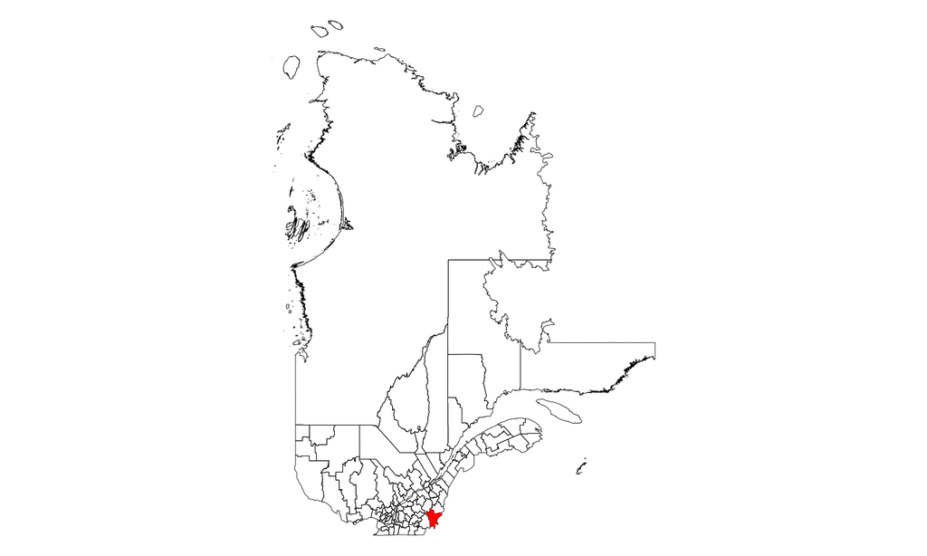

```r
par(mar=rep(0,4))
plot(bouCAN2_Q, lwd=.4)
plot(bouCAN2_Q[id,], add=T, border = NA, col = 2)
```

```r
ra_elv <- rasterize(bouCAN2_Q[id,], crop(altCAN, bouCAN2_Q[id,]@bbox), mask=TRUE)
ra_elv
```

```
## class       : RasterLayer
## dimensions  : 87, 120, 10440  (nrow, ncol, ncell)
## resolution  : 0.008333333, 0.008333333  (x, y)
## extent      : -71.39167, -70.39167, 45.23333, 45.95833  (xmin, xmax, ymin, ymax)
## coord. ref. : +proj=longlat +datum=WGS84 +ellps=WGS84 +towgs84=0,0,0
## data source : in memory
## names       : CAN_msk_alt
## values      : 243, 1103  (min, max)
```

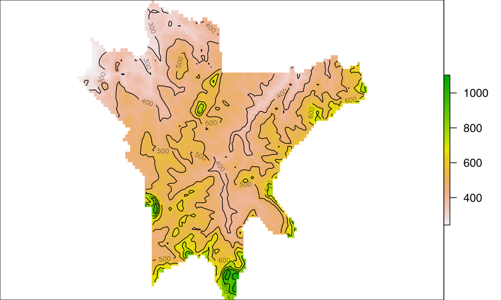

```r
par(mar=rep(0,4))
plot(ra_elv)
contour(ra_elv, add=T)
```

```r
buf <- gBuffer(alex, FALSE, width = .001)
buf
```

```
## class       : SpatialPolygons
## features    : 1
## extent      : -71.11806, -71.1066, 45.44112, 45.46517  (xmin, xmax, ymin, ymax)
## coord. ref. : +proj=longlat +datum=WGS84 +no_defs +ellps=WGS84 +towgs84=0,0,0
```

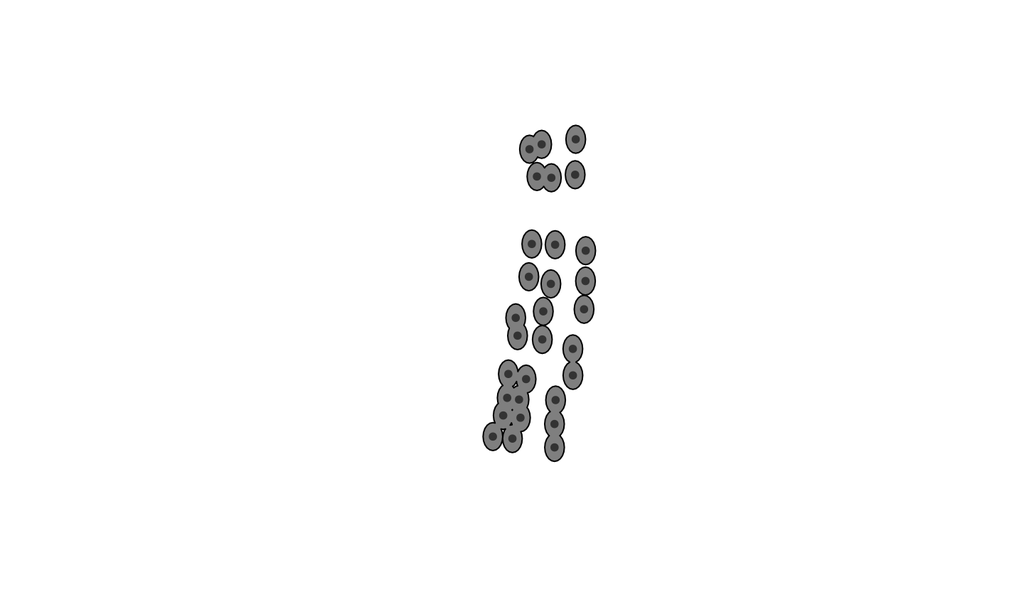

```r
plot(buf, col ="grey50")
plot(alex, add = TRUE, pch=20, col="grey20")
```

```r
altCAN2 <- raster('assets/srtm_22_03.tif')
ra_elv2 <- rasterize(bouCAN2_Q[id,], crop(altCAN2, bouCAN2_Q[id,]@bbox), mask = TRUE)
alex@data$totalC <- runif(nrow(alex@data), 5, 50)
alex@data$categ <- rep(1:3, 10)
alex@data$elv2 <- extract(ra_elv, alex)
alex@data$elv3 <- extract(ra_elv2, alex)
head(alex@data)
```

```
##      plot     elev   totalC categ elv2 elv3
## 1 M-FT-01 749.4448 10.49777     1  802  723
## 2 M-FB-01 908.9915 11.29750     2  802  910
## 3 M-FM-01 848.7617 48.26493     3  802  834
## 4 M-FB-02 909.0892 18.43345     1  862  886
## 5 M-FM-02 833.5641 24.32812     2  802  815
## 6 M-FT-02 738.8082 37.34865     3  802  737
```

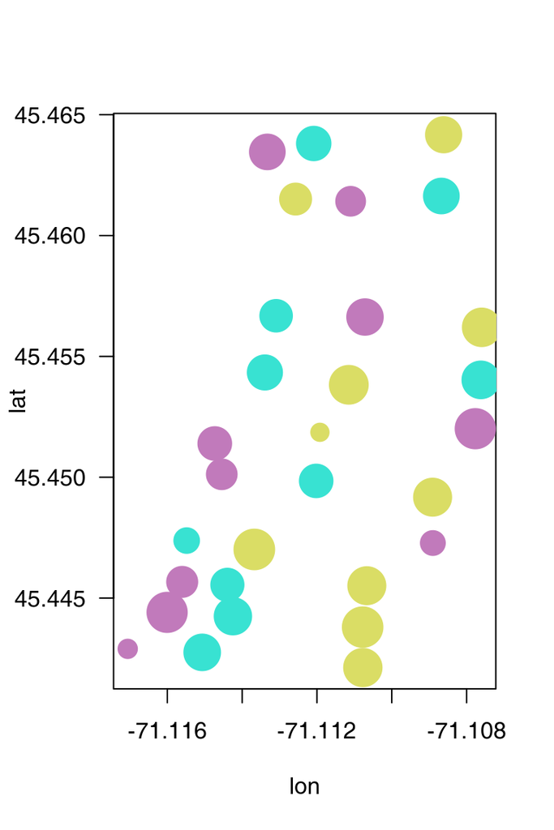

```r
par(las=1)
palette(c('#c17abb', '#38e2d2', '#dadd65'))
plot(t(alex@bbox), type = 'n')
plot(alex, add=T, cex = log(alex@data$totalC), pch = 19, col = alex@data$categ)
```